# W06-1: Visualizing data

Christian Höfs, Jonas Hagge und Stefan Pinkert

31 Januar 2017

Load the merged world bank data set and merge it with the region list #####

Make some plots [1] Please extend the R script given below to create one visualization for each of CO2 and GNI which allows us to get an estimate over the distribution function of the parameters.

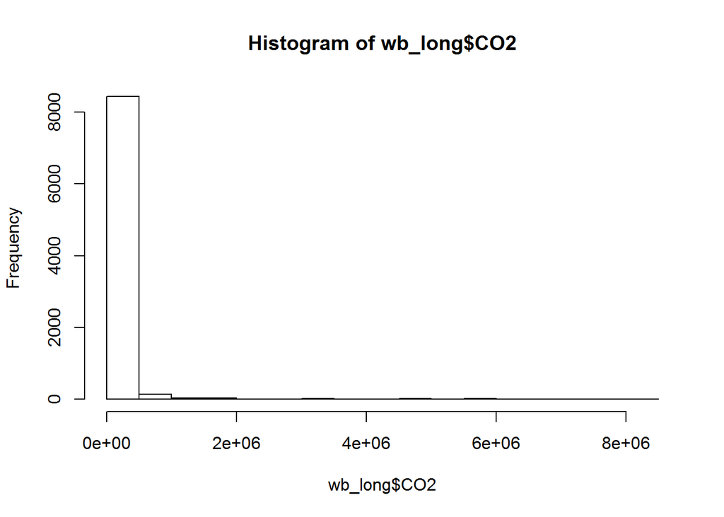

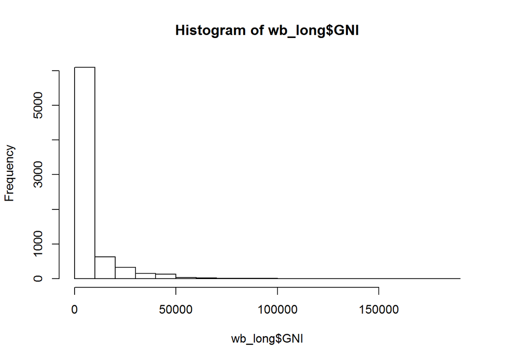

[2] Based on the visualization results above, please extend your script to include an appropriate transformation of the CO2 and GNI values to get their distribution a little bit closer to a normal distribution. Save the result as part of your data frame (i.e. new columns) and visualize the results again (using the same visualization type as above).

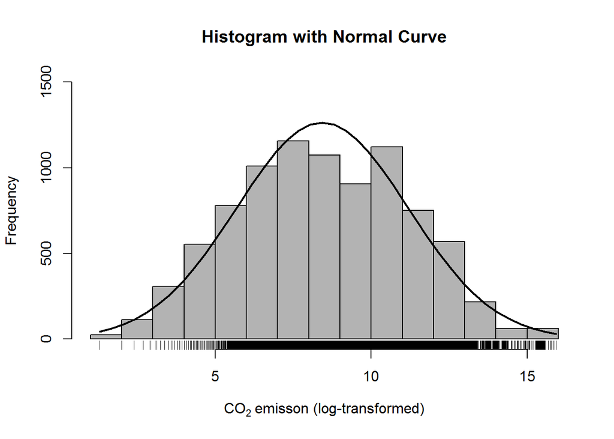

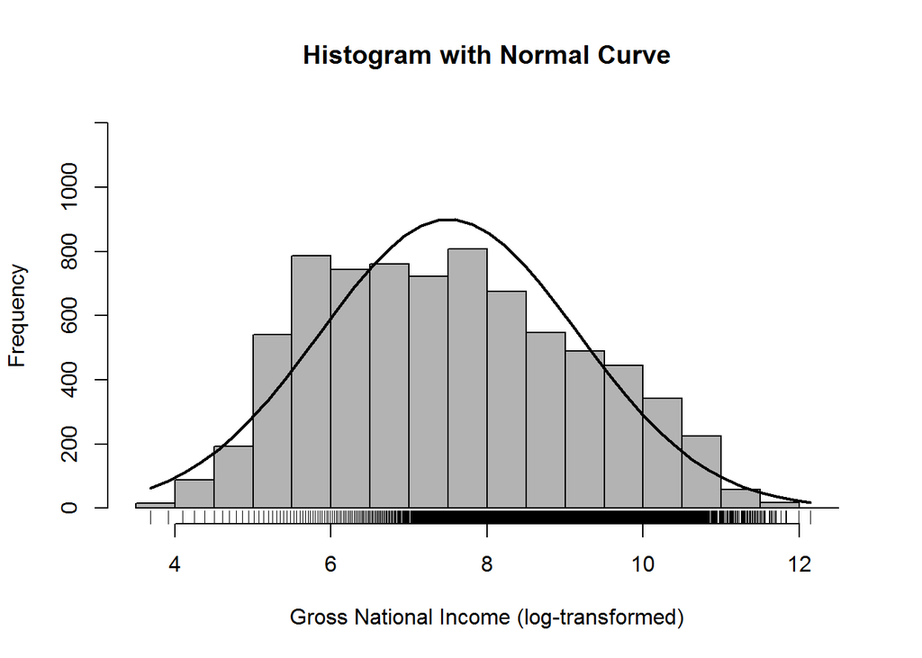

[3] Please extend the script to include two box whisker plots which respectively summarize the CO2 and GNI value distribution for each of the world bank regions.

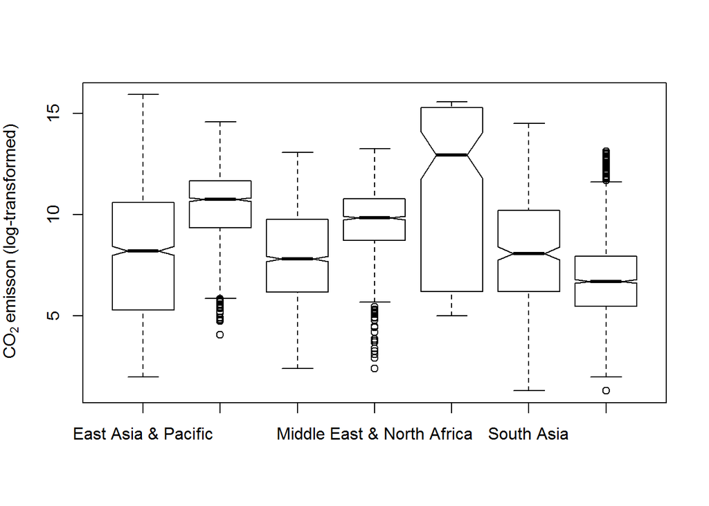

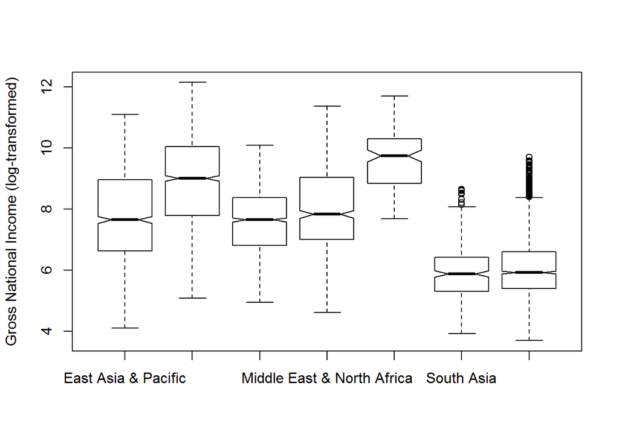

[4] Finally, please visualize the correlation between all CO2 and GNI values in one plot and upload your final script to your learning log.

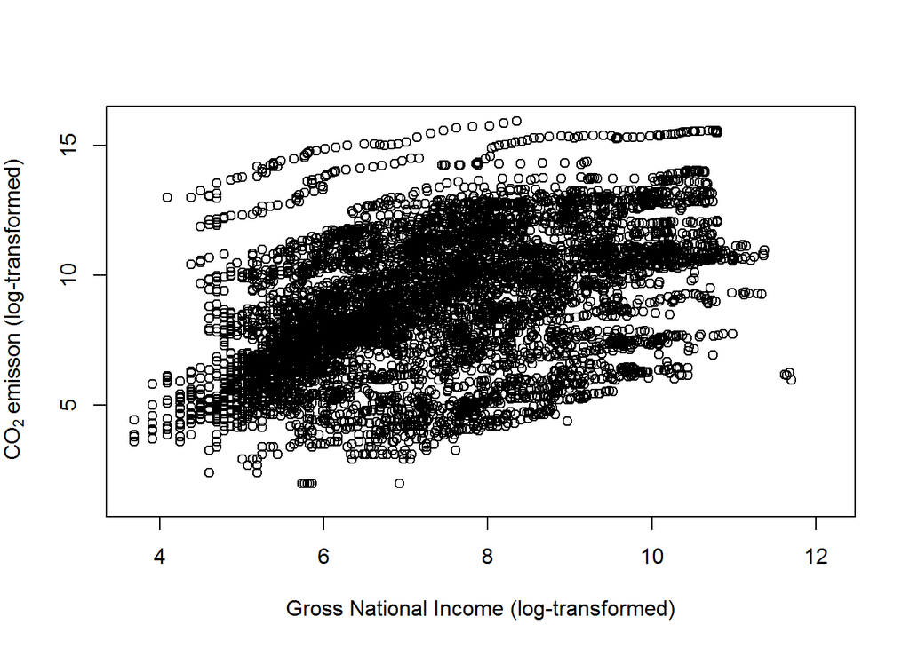